# Calculator в действии

Вадим Хайтов

Цитирую.

*“хорошо. почему для соленого баренцева моря как исходная данность частота язычка у едулис 0,63, а твоя модель описывает от 0.30?”*

**Это не так!** Для использования калкулятора нам необходимо знать частоту Т морфотипа в изучаемом регионе. В неопресненном Баренцевом море эта величина составяет P_T = 0.7280832 (см. в таблицу). Нанесем эту величину на график (черная вертикальная линия).

### Таблица с частотами всех возможных величин

```r
probs_calc_3 <- function(variable = "Location", place = "white_normal", P_MT = 0.5) {
  n <- which(names(myt2) == variable)
  d <- myt2[myt2[,n] == place, ]
  dd <- melt(table(d$Sp, d$morph))
  freq_dd <- dcast(data = dd, formula = Var2 ~ Var1)

  P_T_MT <- round(with(data = freq_dd, M.trossulus[2] /(M.trossulus[2] + M.trossulus[1])), 2)
  P_T_ME <- round(with(data = freq_dd, M.edulis[2] /(M.edulis[2] + M.edulis[1])), 2)
  # P_ME <- round(with(data = freq_dd, sum(M.edulis) /(sum(freq_dd[,-1]))), 2)

  P_E_ME <- round(with(data = freq_dd, M.edulis[1] /(M.edulis[1] + M.edulis[2])), 2)
  P_E_MT <- round(with(data = freq_dd, M.trossulus[1] /(M.trossulus[1] + M.trossulus[2])), 2)
  # P_MT <- round(with(data = freq_dd, sum(M.trossulus) /(sum(freq_dd[,-1]))), 2)


  P_MT_T <- (P_T_MT*P_MT)/(P_T_MT*P_MT + P_T_ME*(1-P_MT))
  P_ME_E <- (P_E_ME*(1-P_MT))/(P_E_ME*(1-P_MT) + P_E_MT*P_MT)

  c(P_MT_T, P_ME_E)
}



freq_calc2 <- function(variable = "Location", place = "barents_fresh"){
  n <- which(names(myt2) == variable)
  d <- myt2[myt2[,n] == place, ]
  dd <- melt(table(d$Sp, d$morph))
  freq_dd <- dcast(data = dd, formula = Var2 ~ Var1)

  #Вероятность встретить M,trossulus среди Т морфотипа оценка условной веротяности P_MT|T
  P_MT_T <- freq_dd$M.trossulus[2]/(freq_dd$M.trossulus[2] + freq_dd$M.edulis[2])

  #Вероятность встретить M.edulis среди E морфотипа
  P_ME_E <- freq_dd$M.edulis[1]/(freq_dd$M.edulis[1] + freq_dd$M.trossulus[1])

  #Вероятность встретить M.trossulus среди E морфотипа
  P_MT_E <- freq_dd$M.trossulus[1]/(freq_dd$M.edulis[1] + freq_dd$M.trossulus[1])

  #Вероятность встретить M.edulis среди T морфотипа
  P_ME_T <- freq_dd$M.edulis[2]/(freq_dd$M.edulis[2] + freq_dd$M.trossulus[2])

  #Вероятность встретить T морфотп среди M.trossulus морфотипа
  P_T_MT <- freq_dd$M.trossulus[2]/(freq_dd$M.trossulus[2] + freq_dd$M.trossulus[1])

  #Вероятность встретить E морфотп среди M.trossulus морфотипа
  P_E_MT <- freq_dd$M.trossulus[1]/(freq_dd$M.trossulus[2] + freq_dd$M.trossulus[1])

  #Вероятность встретить T морфотп среди M.edulis морфотипа
  P_T_ME <- freq_dd$M.edulis[2]/(freq_dd$M.edulis[2] + freq_dd$M.edulis[1])

  #Вероятность встретить E морфотп среди M.edlis морфотипа
  P_E_ME <- freq_dd$M.edulis[1]/(freq_dd$M.edulis[2] + freq_dd$M.edulis[1])

  #Вероятность встретить M.trossulus любого морфотипа
  P_MT   <- sum(freq_dd$M.trossulus)/(sum(freq_dd$M.trossulus) + sum(freq_dd$M.edulis))

  #Вероятность встретить M.edulis любого морфотипа
  P_ME   <- sum(freq_dd$M.edulis)/(sum(freq_dd$M.trossulus) + sum(freq_dd$M.edulis))

  #Вероятность встретить M.trossulus T морфотипа
  P_MT_of_T   <- (freq_dd$M.trossulus[2])/(sum(freq_dd$M.trossulus) + sum(freq_dd$M.edulis))

  #Вероятность встретить M.trossulus E морфотипа
  P_MT_of_E   <- (freq_dd$M.trossulus[1])/(sum(freq_dd$M.trossulus) + sum(freq_dd$M.edulis))

  #Вероятность встретить M.edulis T морфотипа
  P_ME_of_T   <- (freq_dd$M.edulis[2])/(sum(freq_dd$M.trossulus) + sum(freq_dd$M.edulis))

  #Вероятность встретить M.edulis E морфотипа
  P_ME_of_E   <- (freq_dd$M.edulis[1])/(sum(freq_dd$M.trossulus) + sum(freq_dd$M.edulis))

  #Вероятность встретить  E морфотип
  P_E   <- sum(freq_dd[1, -1])/sum(freq_dd[,-1])

  #Вероятность встретить  T морфотип
  P_T   <- sum(freq_dd[2, -1])/sum(freq_dd[,-1])


  props <- c(P_MT_T, P_ME_E, P_MT_E, P_ME_T, P_T_MT, P_E_MT, P_T_ME,  P_E_ME, P_MT, P_ME, P_MT_of_T, P_MT_of_E, P_ME_of_T, P_ME_of_E, P_E, P_T)

  names(props) <- c("P_MT_T", "P_ME_E", "P_MT_E", "P_ME_T", "P_T_MT", "P_E_MT", "P_T_ME",  "P_E_ME", "P_MT", "P_ME", "P_MT_of_T", "P_MT_of_E", "P_ME_of_T", "P_ME_of_E", "P_E", "P_T")

  props
}


All_freq <- data.frame(barents_normal = freq_calc2(place = "barents_normal"),
                       barents_fresh = freq_calc2(place = "barents_fresh"),
                       white_normal = freq_calc2(place = "white_normal"),
                       white_fresh = freq_calc2(place = "white_fresh"))
kable(All_freq)
```

|  | barents_normal | barents_fresh | white_normal | white_fresh |
| --- | --- | --- | --- | --- |
| P_MT_T | 0.5408163 | 0.8742857 | 0.7692308 | 0.9112903 |
| P_ME_E | 0.7103825 | 0.7510549 | 0.8984911 | 0.5952381 |
| P_MT_E | 0.2896175 | 0.2489451 | 0.1015089 | 0.4047619 |
| P_ME_T | 0.4591837 | 0.1257143 | 0.2307692 | 0.0887097 |
| P_T_MT | 0.8333333 | 0.7216981 | 0.6837607 | 0.8692308 |
| P_E_MT | 0.1666667 | 0.2783019 | 0.3162393 | 0.1307692 |
| P_T_ME | 0.6338028 | 0.1100000 | 0.0682788 | 0.3055556 |
| P_E_ME | 0.3661972 | 0.8900000 | 0.9317212 | 0.6944444 |
| P_MT | 0.4725111 | 0.5145631 | 0.2497332 | 0.7831325 |
| P_ME | 0.5274889 | 0.4854369 | 0.7502668 | 0.2168675 |
| P_MT_of_T | 0.3937593 | 0.3713592 | 0.1707577 | 0.6807229 |
| P_MT_of_E | 0.0787519 | 0.1432039 | 0.0789755 | 0.1024096 |
| P_ME_of_T | 0.3343239 | 0.0533981 | 0.0512273 | 0.0662651 |
| P_ME_of_E | 0.1931649 | 0.4320388 | 0.6990395 | 0.1506024 |
| P_E | 0.2719168 | 0.5752427 | 0.7780149 | 0.2530120 |
| P_T | 0.7280832 | 0.4247573 | 0.2219851 | 0.7469880 |

# Калькулятор

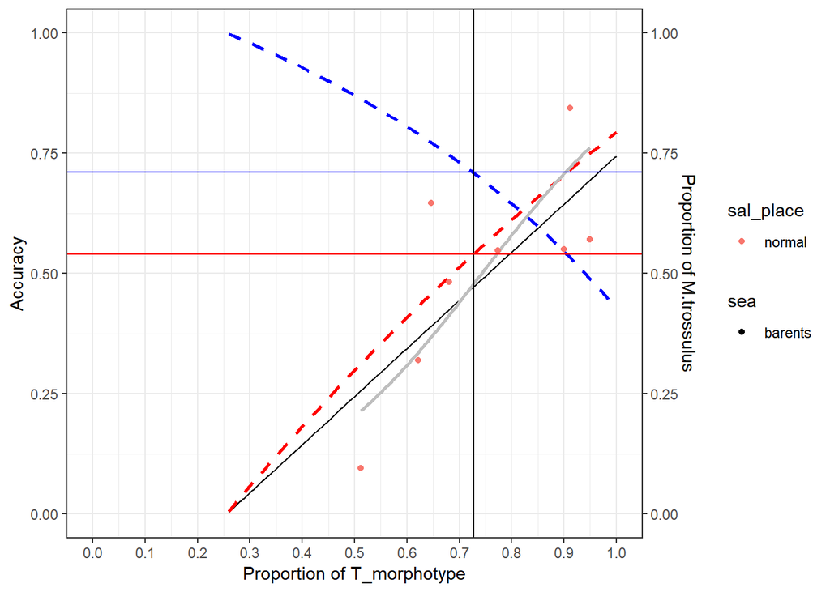

```r
P_MT_calc2 <- function(P_T=0.5, P_MT_of_E, P_ME_of_T){
  P_MT <-P_T + (P_MT_of_E - P_ME_of_T)
  P_MT

}



props <- expand.grid(Prop_T = seq(0, 1, 0.01), sea = c("barents", "white"), sal_place = c("fresh", "normal"))

props$place <- paste(props$sea,"_", props$sal_place, sep = "")


for(i in 1:nrow(props)){
  freq_calc_result <- freq_calc2(place = props$place[i])

  P_MT_of_E <-   freq_calc_result [12]
  P_ME_of_T <-  freq_calc_result [13]

  props$Prop_MT [i] <- P_MT_calc2(P_T = props$Prop_T[i], P_MT_of_E = P_MT_of_E, P_ME_of_T = P_ME_of_T )
  props$P_MT_T [i] <- probs_calc_3(place = props$place[i], P_MT = props$Prop_MT[i])[1]
  props$P_ME_E [i] <- probs_calc_3(place = props$place[i], P_MT = props$Prop_MT[i])[2]
}




Pl_calc <- ggplot(props, aes(x = Prop_T, y = Prop_MT)) + geom_line(color = "black") + facet_grid(sea~sal_place) + geom_line(aes(y=P_MT_T), color = "red", linetype = 2, size = 1) + geom_line(aes(y=P_ME_E), color = "blue", linetype = 2, size = 1) + geom_line(data = new_data, aes(x = Prop_T, y = fit), color = "gray", size = 1) + labs(x="Proportion of T_morphotype", y = "Accuracy")  + theme_bw() +  scale_x_continuous(breaks = seq(0, 1, 0.1)) + geom_point(data = prop_T_MT, aes(x = Prop_T, y = Prop_MT, color = sal_place, shape = sea))  + scale_y_continuous( sec.axis = sec_axis(trans = ~., name = "Proportion of M.trossulus"), limits = c(0,1) )

Pl_calc_barents_normal <- ggplot(data = props[ props$place == "barents_normal", ], aes(x = Prop_T, y = Prop_MT)) + geom_line(color = "black")  + geom_line(aes(y=P_MT_T), color = "red", linetype = 2, size = 1) + geom_line(aes(y=P_ME_E), color = "blue", linetype = 2, size = 1) + geom_line(data = new_data [new_data$sea =="barents" & new_data$sal_place == "normal",  ], aes(x = Prop_T, y = fit), color = "gray", size = 1) + labs(x="Proportion of T_morphotype", y = "Accuracy")  + theme_bw()+  scale_x_continuous(breaks = seq(0, 1, 0.1)) + geom_point(data = prop_T_MT[prop_T_MT$sea == "barents" & prop_T_MT$sal_place == "normal", ], aes(x = Prop_T, y = Prop_MT, color = sal_place, shape = sea))  + scale_y_continuous( sec.axis = sec_axis(trans = ~., name = "Proportion of M.trossulus"), limits = c(0,1) )

P_T <-  0.7280832

P_ME_E_predicted <- round(props[ props$place == "barents_normal" & props$Prop_T == round(P_T, 2), ]$P_ME_E, 2)

P_MT_T_predicted <- round(props[ props$place == "barents_normal" & props$Prop_T == round(P_T, 2), ]$P_MT_T, 2)

Pl_calc_barents_normal + geom_vline(xintercept =  P_T) + geom_hline(yintercept = P_ME_E_predicted, color = "blue") + geom_hline(yintercept = P_MT_T_predicted, color = "red")
```

```r
P_T_ME_predicted <-((1-P_MT_T_predicted)*P_T)/((1-P_MT_T_predicted)*P_T + P_ME_E_predicted*(1-P_T))
```

Находим точку пересечения с синей пунктирной линией – это дает нам величину P_ME_E = 0.71. Аналогично находим P_MT_T, как пересечение с красной прерывистой линией: P_MT_T = 0.54. С табличным совпадает!  
Далее, нам надо на основе этих данных найти вероятность иметь язычок при условии, что мы знаем, что мидия относится к виду M.edulis, в наших обозначениях это P_T_ME (еще раз, **не путаем** понятия P_T_ME и P_ME_T!!!). Эта величина, действительно, равна P_T_ME = 0.6338028 (см. таблицу).  
Для вычисления этой величины на основе данных, полученных из калькулятора, нужно воспользоваться теоремой Байеса (увы, только так). Искомая величина $P_{T|ME}$,то есть частота T-морфотипа среди M.edulis (или, что правильнее, “вероятность встретить Т-морфотип при условии, что мы знаем, что мидия относится к M.edulis”, знак “|” означает “при условии”), будет вычисляться вот так:

$$P_{T|ME} = \frac{P_{ME|T} \cdot P_T}{P_{ME|T} \cdot P_T + P_{ME|E} \cdot P_E}$$

Величину $P_{ME|E}$ мы уже знаем из калькулятора (P_ME_E, см. выше). Величина $P_{ME|T}$, с очевидностью, равна $1-P_{MT|T}$, а $P_E = 1-P_T$. Тогда уравнение становится вот таким:

$$P_{T|ME} = \frac{(1-P_{MT|T}) \cdot P_T}{(1-P_{MT|T}) \cdot P_T + P_{ME|E} \cdot (1-P_T)}$$

Но, $P_{MT|T}$ мы тоже знаем из калькулятора. Подставляем циферки:

$$P_{T|ME} = \frac{(1- 0.54) \cdot 0.7280832}{(1-0.54) \cdot 0.7280832 + 0.71 \cdot (1-0.7280832)}$$

Ответ: 0.63.